# Итоговое экзаменационное задание

Проверка освоения курса R. Анализ взаимосвязи страхового рынка и финансово-экономических показателей стран мира

Mironkina Yuliya

July 12, 2018

Признаюсь: это было совсем непросто! :)

Данные я решила взять связанные с моими научными интересами. Источник данных [The World Bank] (https://data.worldbank.org/indicator/) В работе будет предпринята попытка *проанализировать взаимосвязи между развитием страхового рынка и различными социально-экономическими и финансовыми показателями развития стран мира*.

# 1 Подготовка к анализу данных

## 1.1 Подключение необходимых пакетов

```r
library(tidyverse) # обработка данных, графики...
library(dplyr)
library(skimr)# описательные статистики
library(rio) # импорт фантастического количества форматов данных
library(lattice) #для графиков
library(DataExplorer) #для быстрого автоматического графического анализа
library(cluster) # кластерный анализ
library(factoextra) # визуализации kmeans, pca,
library(dendextend) # визуализация дендрограмм
library(corrplot) # визуализация корреляций
library(broom) # метла превращает результаты оценивания моделей в таблички
library(naniar) # визуализация пропущенных значений
library(visdat) # визуализация пропущенных значений
library(patchwork) # удобное расположение графиков рядом
library(GGally) # больше готовых графиков
library(sjPlot) # ещё больше графиков
devtools::install_github("strengejacke/strengejacke")
library(lmtest) # диагностика линейных моделей
library(sjstats) # удобные мелкие функции для работы с моделями
 library(sandwich) # оценка Var для гетероскедастичности
library(AER) # работа с инструментальными переменными
library(huxtable) # красивые таблички в html, tex
library(stargazer) # красивые таблички в html, tex
library(texreg) # и снова красивые таблички в html, tex :)
library(estimatr) # модели с робастными ошибками
library(sandwich) # оценка Var для гетероскедастичности
library(caret) # пакет для подбора параметров разных моделей
library(FFTrees) # быстрые деревья
library(margins) # для подсчёта предельных эффектов
library(rpart.plot) # для картинок деревьев
library(plotROC) # визуализация ROC-кривой
library(ggeffects) # графики для предельных эффектов
library(MLmetrics) # метрики качества
library(ranger) # случайный лес
library(elasticnet) # LASSO
library(latex2exp) # формулы в подписях к графику
library(distances) # расчет различных расстояний
library(texreg) # таблички со сравнением моделей
library(vcd)
```

## 1.2 Импорт данных из Excel и описательный анализ

```r
data <- import('Data_R.xlsx')
glimpse(data)
```

```
## Observations: 59
## Variables: 21
## $ Country                <chr> "Algeria", "Angola", "Argentina", "Aust...
## $ Continents             <chr> "Africa", "Africa", "America", "Oceania...
## $ Insurance_dencity      <dbl> 30.0, 30.5, 325.5, 3397.1, 10.2, 346.3,...
## $ Broad_money            <dbl> 79.37294, 41.80495, 28.93965, 118.53327...
## $ Commercial_bank        <dbl> 5.234463, 10.286108, 13.368897, 27.7960...
## $ Education              <dbl> 10, 6, 14, 10, 5, 14, 11, 13, 10, 11, 8...
## $ Employment_services    <dbl> 54.4, 58.4, 73.2, 75.9, 39.4, 63.3, 63....
## $ Exports                <dbl> 21.00176, 30.03023, 12.77560, 18.86783,...
## $ GDP_per_capita         <dbl> 3916.882, 3308.700, 12440.321, 49755.31...
## $ Inflation_GDP_deflator <dbl> 0.88990389, 27.42131464, 40.67530965, -...
## $ International_tourism  <dbl> 0.7892833, 3.2076979, 15.8074874, 11.68...
## $ Labor_force_rate       <dbl> 41.40755, 77.67647, 59.96354, 64.89297,...
## $ Net_trade              <dbl> -19959177831, 14548384198, 4540497887, ...
## $ Population_density     <dbl> 17.048895, 23.111786, 16.022067, 3.1515...
## $ Unemployment           <dbl> 11.5, 6.1, 8.8, 5.7, 4.1, 11.5, 7.6, 6....
## $ Life_nonlife           <dbl> 0.08333333, 0.01639344, 0.16405530, 0.4...
## $ Life_is_more           <chr> "no", "no", "no", "no", "yes", "yes", "...
## $ Life                   <dbl> 2.5, 0.5, 53.4, 1558.5, 7.5, 195.5, 28....
## $ `Non-life`             <dbl> 27.4, 30.0, 272.2, 1838.6, 2.7, 150.8, ...
## $ Net_trade_per_capita   <dbl> -491.53210, 504.91620, 103.55220, -237....
## $ Y_net_trade            <chr> "negativ", "positiv", "positiv", "negat...
```

Видим, что имеем набор из наблюдений 59 стран по 21 переменным. Из них 4 переменные восприняты как текстовые (две из них - Country и Continents таковыми, действительно, являются, первую так и оставим как названия стран, вторую переведем в факторную), и еще две (Life_is_more и Y_net_trade) необходимо перевести в факторные.

```r
data <- mutate(data, Continents = factor(Continents), Life_is_more = factor(Life_is_more), Y_net_trade = factor(Y_net_trade))
skim(data)
```

| variable | type | stat | level | value | formatted |
| --- | --- | --- | --- | --- | --- |
| Country | character | missing | .all | 0 | 0 |
| Country | character | complete | .all | 59 | 59 |
| Country | character | n | .all | 59 | 59 |
| Country | character | min | .all | 4 | 4 |
| Country | character | max | .all | 20 | 20 |
| Country | character | empty | .all | 0 | 0 |
| Country | character | n_unique | .all | 59 | 59 |
| Continents | factor | missing | .all | 0 | 0 |
| Continents | factor | complete | .all | 59 | 59 |
| Continents | factor | n | .all | 59 | 59 |
| Continents | factor | n_unique | .all | 6 | 6 |
| Continents | factor | top_counts | America | 14 | Ame: 14 |
| Continents | factor | top_counts | Europe | 14 | Eur: 14 |
| Continents | factor | top_counts | Asia | 12 | Asi: 12 |
| Continents | factor | top_counts | Africa | 9 | Afr: 9 |
| Continents | factor | top_counts | East | 9 | Eas: 9 |
| Continents | factor | top_counts | Oceania | 1 | Oce: 1 |
| Continents | factor | top_counts |  | 0 | NA: 0 |
| Continents | factor | ordered | .all | 0 | FALSE |
| Insurance_dencity | numeric | missing | .all | 0 | 0 |
| Insurance_dencity | numeric | complete | .all | 59 | 59 |
| Insurance_dencity | numeric | n | .all | 59 | 59 |
| Insurance_dencity | numeric | mean | .all | 892 | 891.52 |
| Insurance_dencity | numeric | sd | .all | 1.53e+03 | 1526.11 |
| Insurance_dencity | numeric | p0 | .all | 6.2 | 6.2 |
| Insurance_dencity | numeric | p25 | .all | 79.7 | 79.7 |
| Insurance_dencity | numeric | p50 | .all | 269 | 268.6 |
| Insurance_dencity | numeric | p75 | .all | 626 | 625.8 |
| Insurance_dencity | numeric | p100 | .all | 6.93e+03 | 6933.5 |
| Insurance_dencity | numeric | hist | .all |  | ▇▁▁▁▁▁▁▁ |

[output cut: 192 more lines]

Теперь все в порядке - у нас 59 стран, по ним по 3 факторных переменных и по 17 числовых. Пропусков нет. Опишем переменные, участвующие в исследовании:

```r
data_description <- import('Data_R_description.xlsx')
knitr::kable(data_description)
```

| Country | Country__1 | Страна |
| --- | --- | --- |
| Continents | Continent | Континент |
| Insurance_dencity | Total business insurance dencity premiums per capita in USD in 2016 | Плотность страхования - объем страховых премий на душу населения ($ США) |
| Broad_money | Broad money (% of GDP) | Широкая денежная масса (% от ВВП) |
| Commercial_bank | Commercial bank branches (per 100,000 adults) | Количество отделений коммерческих банков (на 100 000 взрослых) |
| Education | Compulsory education, duration (years) | Обязательное образование, продолжительность (лет) |
| Employment_services | Employment in services (% of total employment) (modeled ILO estimate) | Занятость в сфере услуг (%от общей занятости) (смоделированная оценка МОТ) |
| Exports | Exports of goods and services (% of GDP) | Экспорт товаров и услуг (% от ВВП) |
| GDP_per_capita | GDP per capita (current US$) | ВВП на душу населения (в долларах США$) |
| Inflation_GDP_deflator (annual %) | Inflation, GDP deflator (annual %) | Инфляция, дефлятор ВВП (годовой %) |
| International_tourism | International tourism, expenditures (% of total imports) | Международный туризм, расходы (% от общего объема импорта) |
| Labor_force_rate | Labor force participation rate, total (% of total population ages 15+) (modeled ILO estimate) | Коэффициент участия рабочей силы (%от общей численности населения в возрасте 15+) (смоделированная оценка МОТ) |
| Net_trade | Net trade in goods (BoP, current US$) | Чистая торговля товарами ( в долларах США$) |
| Population_density | Population density (people per sq. km of land area) | Плотность населения (чел. на кв. км земельного участка) |
| Unemployment | Unemployment, total (% of total labor force) (modeled ILO estimate) | Безработица, всего (%от общей численности рабочей силы) (смоделированная оценка МОТ) |
| Life_nonlife | share of life insurance in total insurance | Доля страхования жизни в общем объеме страхования |
| Life_is_more | Life_non life more then 50% | Преобладание страхования жизни в общем объеме страховых премий |
| Life | Life business | Объем премий по страхованию жизни на душу населения ($ США) |
| Non-life | Non-life business | Объем премий по страхованию не-жизни на душу населения ($ США) |
| Net_trade_per_capita | Net trade in goods (BoP, current US$) per capita | Чистая торговля товарами ( в долларах США$) на душу населения |
| Y_net_trade | Y(0;1) | Posistiv - если положительная величина Net_trade (преобладает |

Посмотреть на набор данных можно с помощью различных функций.

```r
glimpse(data) # Показывает все значения переменных в строчку (первые наблюдения)
```

```
## Observations: 59
## Variables: 21
## $ Country                <chr> "Algeria", "Angola", "Argentina", "Aust...
## $ Continents             <fct> Africa, Africa, America, Oceania, Asia,...
## $ Insurance_dencity      <dbl> 30.0, 30.5, 325.5, 3397.1, 10.2, 346.3,...
## $ Broad_money            <dbl> 79.37294, 41.80495, 28.93965, 118.53327...
## $ Commercial_bank        <dbl> 5.234463, 10.286108, 13.368897, 27.7960...
## $ Education              <dbl> 10, 6, 14, 10, 5, 14, 11, 13, 10, 11, 8...
## $ Employment_services    <dbl> 54.4, 58.4, 73.2, 75.9, 39.4, 63.3, 63....
## $ Exports                <dbl> 21.00176, 30.03023, 12.77560, 18.86783,...
## $ GDP_per_capita         <dbl> 3916.882, 3308.700, 12440.321, 49755.31...
## $ Inflation_GDP_deflator <dbl> 0.88990389, 27.42131464, 40.67530965, -...
## $ International_tourism  <dbl> 0.7892833, 3.2076979, 15.8074874, 11.68...
## $ Labor_force_rate       <dbl> 41.40755, 77.67647, 59.96354, 64.89297,...
## $ Net_trade              <dbl> -19959177831, 14548384198, 4540497887, ...
## $ Population_density     <dbl> 17.048895, 23.111786, 16.022067, 3.1515...
## $ Unemployment           <dbl> 11.5, 6.1, 8.8, 5.7, 4.1, 11.5, 7.6, 6....
## $ Life_nonlife           <dbl> 0.08333333, 0.01639344, 0.16405530, 0.4...
## $ Life_is_more           <fct> no, no, no, no, yes, yes, no, yes, no, ...
## $ Life                   <dbl> 2.5, 0.5, 53.4, 1558.5, 7.5, 195.5, 28....
## $ `Non-life`             <dbl> 27.4, 30.0, 272.2, 1838.6, 2.7, 150.8, ...
## $ Net_trade_per_capita   <dbl> -491.53210, 504.91620, 103.55220, -237....
## $ Y_net_trade            <fct> negativ, positiv, positiv, negativ, neg...
```

```r
head(data) # Показывает "шапку" таблицы данных - первые 6 строк таблицы
```

| Country | Continents | Insurance_dencity | Broad_money | Commercial_bank | Education | Employment_services | Exports | GDP_per_capita | Inflation_GDP_deflator | International_tourism | Labor_force_rate | Net_trade | Population_density | Unemployment | Life_nonlife | Life_is_more | Life | Non-life | Net_trade_per_capita | Y_net_trade |
| --- | --- | --- | --- | --- | --- | --- | --- | --- | --- | --- | --- | --- | --- | --- | --- | --- | --- | --- | --- | --- |
| Algeria | Africa | 30 | 79.4 | 5.23 | 10 | 54.4 | 21 | 3.92e+03 | 0.89 | 0.789 | 41.4 | -2e+10 | 17 | 11.5 | 0.0833 | no | 2.5 | 27.4 | -492 | negativ |
| Angola | Africa | 30.5 | 41.8 | 10.3 | 6 | 58.4 | 30 | 3.31e+03 | 27.4 | 3.21 | 77.7 | 1.45e+10 | 23.1 | 6.1 | 0.0164 | no | 0.5 | 30 | 505 | positiv |
| Argentina | America | 326 | 28.9 | 13.4 | 14 | 73.2 | 12.8 | 1.24e+04 | 40.7 | 15.8 | 60 | 4.54e+09 | 16 | 8.8 | 0.164 | no | 53.4 | 272 | 104 | positiv |
| Australia | Oceania | 3.4e+03 | 119 | 27.8 | 10 | 75.9 | 18.9 | 4.98e+04 | -0.414 | 11.7 | 64.9 | -5.74e+09 | 3.15 | 5.7 | 0.459 | no | 1.56e+03 | 1.84e+03 | -238 | negativ |
| Bangladesh | Asia | 10.2 | 65.9 | 8.44 | 5 | 39.4 | 16.6 | 1.36e+03 | 6.73 | 1.76 | 56.4 | -6.22e+09 | 1.25e+03 | 4.1 | 0.735 | yes | 7.5 | 2.7 | -38.2 | negativ |
| Brazil | America | 346 | 100 | 20.4 | 14 | 63.3 | 12.5 | 8.65e+03 | 8.33 | 8.4 | 63.8 | 4.5e+10 | 24.8 | 11.5 | 0.565 | yes | 196 | 151 | 217 | positiv |

```r
tail(data) # Показывает низ таблицы данных - послдние 6 строк таблицы
```

| Country | Continents | Insurance_dencity | Broad_money | Commercial_bank | Education | Employment_services | Exports | GDP_per_capita | Inflation_GDP_deflator | International_tourism | Labor_force_rate | Net_trade | Population_density | Unemployment | Life_nonlife | Life_is_more | Life | Non-life | Net_trade_per_capita | Y_net_trade |
| --- | --- | --- | --- | --- | --- | --- | --- | --- | --- | --- | --- | --- | --- | --- | --- | --- | --- | --- | --- | --- |
| United Arab Emirates | East | 1.1e+03 | 95.7 | 12.4 | 6 | 75.3 | 104 | 3.76e+04 | -5.44 | 5.29 | 80.4 | 4.09e+10 | 111 | 3.8 | 0.239 | no | 264 | 838 | 4.41e+03 | positiv |
| United Kingdom | Europe | 4.06e+03 | 142 | 23.1 | 11 | 80.2 | 27.9 | 4.04e+04 | 2 | 9.95 | 62.4 | -1.83e+11 | 271 | 4.8 | 0.746 | yes | 3.03e+03 | 1.03e+03 | -2.78e+03 | negativ |
| United States | America | 4.17e+03 | 90.3 | 32.7 | 12 | 81.3 | 11.9 | 5.76e+04 | 1.28 | 5.93 | 62.2 | -7.53e+11 | 35.3 | 4.9 | 0.413 | no | 1.72e+03 | 2.45e+03 | -2.33e+03 | negativ |
| Uruguay | America | 372 | 51.2 | 11.4 | 14 | 70.7 | 21.4 | 1.52e+04 | 7.05 | 13.2 | 64.7 | 2.34e+09 | 19.7 | 7.8 | 0.382 | no | 142 | 230 | 679 | positiv |
| Vietnam | Asia | 38.4 | 151 | 3.87 | 10 | 34.5 | 93.6 | 2.17e+03 | 1.11 | 2.53 | 78.2 | 1.4e+10 | 305 | 2.2 | 0.568 | yes | 21.8 | 16.6 | 151 | positiv |
| Russia | Europe | 123 | 59.2 | 30.1 | 11 | 66 | 25.7 | 8.75e+03 | 3.61 | 10.4 | 63.8 | 9.03e+10 | 8.81 | 5.5 | 0.182 | no | 22.4 | 100 | 625 | positiv |

```r
str(data) # показывает структуру данных и по несколько значен й для каждой переменной
```

```
## 'data.frame':    59 obs. of  21 variables:
##  $ Country               : chr  "Algeria" "Angola" "Argentina" "Australia" ...
##  $ Continents            : Factor w/ 6 levels "Africa","America",..: 1 1 2 6 3 2 5 2 2 2 ...
##  $ Insurance_dencity     : num  30 30.5 325.5 3397.1 10.2 ...
##  $ Broad_money           : num  79.4 41.8 28.9 118.5 65.9 ...
##  $ Commercial_bank       : num  5.23 10.29 13.37 27.8 8.44 ...
##  $ Education             : num  10 6 14 10 5 14 11 13 10 11 ...
##  $ Employment_services   : num  54.4 58.4 73.2 75.9 39.4 ...
##  $ Exports               : num  21 30 12.8 18.9 16.6 ...
##  $ GDP_per_capita        : num  3917 3309 12440 49755 1359 ...
##  $ Inflation_GDP_deflator: num  0.89 27.421 40.675 -0.414 6.728 ...
##  $ International_tourism : num  0.789 3.208 15.807 11.687 1.762 ...
##  $ Labor_force_rate      : num  41.4 77.7 60 64.9 56.4 ...
##  $ Net_trade             : num  -2.00e+10 1.45e+10 4.54e+09 -5.74e+09 -6.22e+09 ...
##  $ Population_density    : num  17.05 23.11 16.02 3.15 1251.84 ...
##  $ Unemployment          : num  11.5 6.1 8.8 5.7 4.1 ...
##  $ Life_nonlife          : num  0.0833 0.0164 0.1641 0.4588 0.7353 ...
##  $ Life_is_more          : Factor w/ 2 levels "no","yes": 1 1 1 1 2 2 1 2 1 1 ...
##  $ Life                  : num  2.5 0.5 53.4 1558.5 7.5 ...
##  $ Non-life              : num  27.4 30 272.2 1838.6 2.7 ...
##  $ Net_trade_per_capita  : num  -491.5 504.9 103.6 -237.7 -38.2 ...
##  $ Y_net_trade           : Factor w/ 2 levels "negativ","positiv": 1 2 2 1 1 2 1 2 1 1 ...
```

```r
# create_report(data) создает целый краткий отчет по данным "Data Profiling Report" - все дискриптивные статистики, гистограммы, корреляционная матрица, главные компоненты...
```

Видим, что переменная “Insurance_dencity”, Плотность страхования“, которая будет зависимой затем в регрессиях, имеет асимметричное распределение. И, т.к. она является денежной, прологарифмируем ее и посмотрим гистограмму.

```r
data <- mutate(data, lnY = log(Insurance_dencity))
glimpse(data)
```

```
## Observations: 59
## Variables: 22
## $ Country                <chr> "Algeria", "Angola", "Argentina", "Aust...
## $ Continents             <fct> Africa, Africa, America, Oceania, Asia,...
## $ Insurance_dencity      <dbl> 30.0, 30.5, 325.5, 3397.1, 10.2, 346.3,...
## $ Broad_money            <dbl> 79.37294, 41.80495, 28.93965, 118.53327...
## $ Commercial_bank        <dbl> 5.234463, 10.286108, 13.368897, 27.7960...
## $ Education              <dbl> 10, 6, 14, 10, 5, 14, 11, 13, 10, 11, 8...
## $ Employment_services    <dbl> 54.4, 58.4, 73.2, 75.9, 39.4, 63.3, 63....
## $ Exports                <dbl> 21.00176, 30.03023, 12.77560, 18.86783,...
## $ GDP_per_capita         <dbl> 3916.882, 3308.700, 12440.321, 49755.31...
## $ Inflation_GDP_deflator <dbl> 0.88990389, 27.42131464, 40.67530965, -...
## $ International_tourism  <dbl> 0.7892833, 3.2076979, 15.8074874, 11.68...
## $ Labor_force_rate       <dbl> 41.40755, 77.67647, 59.96354, 64.89297,...
## $ Net_trade              <dbl> -19959177831, 14548384198, 4540497887, ...
## $ Population_density     <dbl> 17.048895, 23.111786, 16.022067, 3.1515...
## $ Unemployment           <dbl> 11.5, 6.1, 8.8, 5.7, 4.1, 11.5, 7.6, 6....
## $ Life_nonlife           <dbl> 0.08333333, 0.01639344, 0.16405530, 0.4...
## $ Life_is_more           <fct> no, no, no, no, yes, yes, no, yes, no, ...
## $ Life                   <dbl> 2.5, 0.5, 53.4, 1558.5, 7.5, 195.5, 28....
## $ `Non-life`             <dbl> 27.4, 30.0, 272.2, 1838.6, 2.7, 150.8, ...
## $ Net_trade_per_capita   <dbl> -491.53210, 504.91620, 103.55220, -237....
## $ Y_net_trade            <fct> negativ, positiv, positiv, negativ, neg...
## $ lnY                    <dbl> 3.401197, 3.417727, 5.785362, 8.130677,...
```

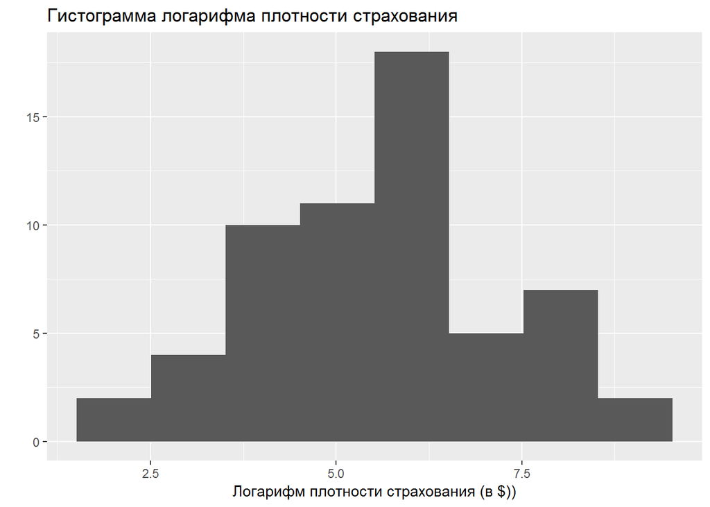

```r
qplot(data = data, x = lnY, bins = 8) + labs(x = 'Логарифм плотности страхования (в $))', title = 'Гистограмма логарифма плотности страхования')
```

# 2 Исследование факторных признаков

## 2.1 Описание факторных переменных

```r
table(data$Continents)
```

```
##
##  Africa America    Asia    East  Europe Oceania
##       9      14      12       9      14       1
```

```r
table(data$Life_is_more)
```

```
##
##  no yes
##  38  21
```

```r
table(data$Y_net_trade)
```

```
##
## negativ positiv
##      31      28
```

Видим, что переменная Continents (Континенты) имеет 6 уровней, в выборке представлены 9 стран из Африки, 14- из Америки, 12 из Азии, 9 из Среднего и Ближнего Востока, 14 - из Европы и 1 срана (Австралия) представляет Океанию. В выборке 21 страна имеет преобладание страхования жизни в общем объеме премий и 38 - характеризуется большим объем премий по не-жизни. У 31 страны преобладает импорт товаров и услуг, у 28 - экспорт (они больше продают, переменная Y_net_trade=“positiv”).

Посмотрим, как связаны категориальные переменные между собой.

## 2.2 Таблицы сопряженности и проверка зависимости

```r
table1 <- table(data$Continents, data$Life_is_more)
table1 # таблица сопряженности континентов и преобладания страхования жизни
```

```
##
##           no yes
##   Africa   6   3
##   America 12   2
##   Asia     2  10
##   East     8   1
##   Europe   9   5
##   Oceania  1   0
```

```r
chisq.test(table1)
```

```
##
##  Pearson's Chi-squared test
##
## data:  table1
## X-squared = 17.629, df = 5, p-value = 0.00345
```

Видим, что преобладание страхования жизни существенно разнится по континентам - в Америке, Африке и на Востоке больше распространено страхование не-жизни, в Азии - страхование жизни. В Европе в среднем половина стран имеет преобладание не-жизни. Хи-квадрат-тест показывает статистическую значимость этих отличий (отвергает гипотезу о независимости переменных на любом разумном уровне значимости).

```r
table2 <- table(data$Continents, data$Y_net_trade)
table2 # таблица сопряженности континентов и преобладания продажи товаров и услуг
```

```
##
##           negativ positiv
##   Africa        7       2
##   America       8       6
##   Asia          5       7
##   East          4       5
##   Europe        6       8
##   Oceania       1       0
```

```r
chisq.test(table2)
```

```
##
##  Pearson's Chi-squared test
##
## data:  table2
## X-squared = 4.6531, df = 5, p-value = 0.4597
```

```r
table3 <- table(data$Y_net_trade, data$Life_is_more)
table3 # таблица сопряженности преобладания продажи товаров и услуг и преобладания страхования жизни
```

```
##
##           no yes
##   negativ 23   8
##   positiv 15  13
```

```r
chisq.test(table3)
```

```
##
##  Pearson's Chi-squared test with Yates' continuity correction
##
## data:  table3
## X-squared = 1.9038, df = 1, p-value = 0.1677
```

Две другие пары факторных переминных демонстрируют независимость между собой согласно критерию хи-квадрат. Построим мозаичные графики, наглядно демонстрирующие полученные выводы

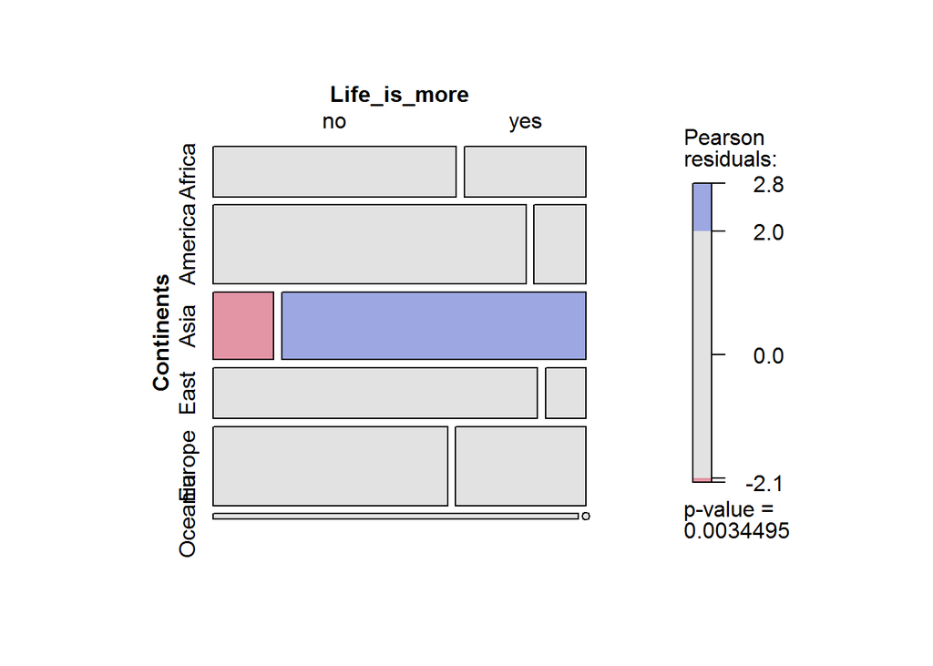

```r
mosaic(data = data, ~ Continents + Life_is_more, shade = TRUE, legend = TRUE)
```

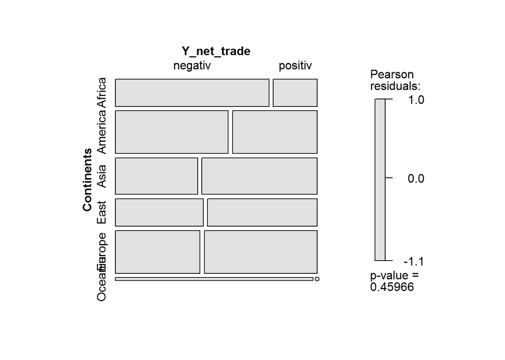

```r
mosaic(data = data, ~ Continents + Y_net_trade, shade = TRUE, legend = TRUE)
```

# 3 Статистический анализ количественных признаков

## 3.1 Диаграммы рассеивания и скрипичные графики

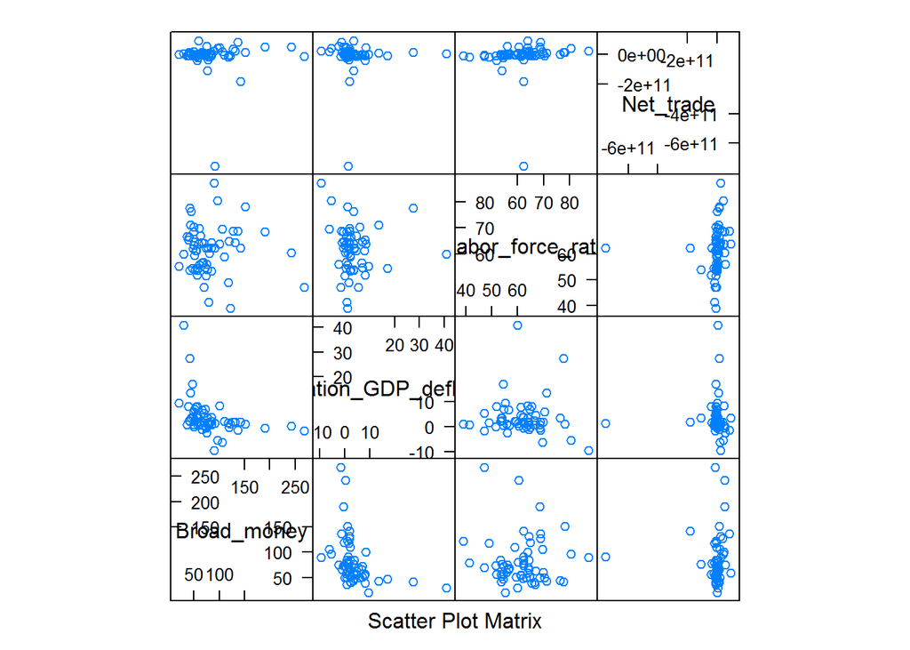

```r
splom(data[c(4, 10, 12, 13)])
```

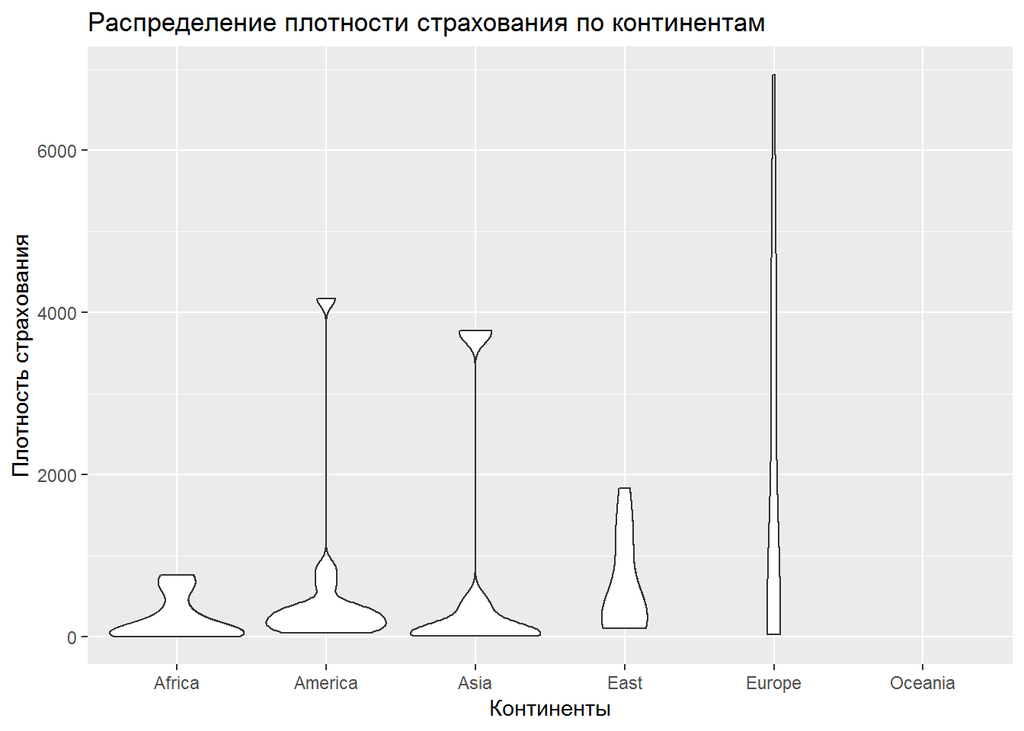

```r
ggplot(data = data) +   geom_violin(aes(x = Continents, y = Insurance_dencity)) +  labs(x = 'Континенты', y = 'Плотность страхования', title = 'Распределение плотности страхования по континентам')
```

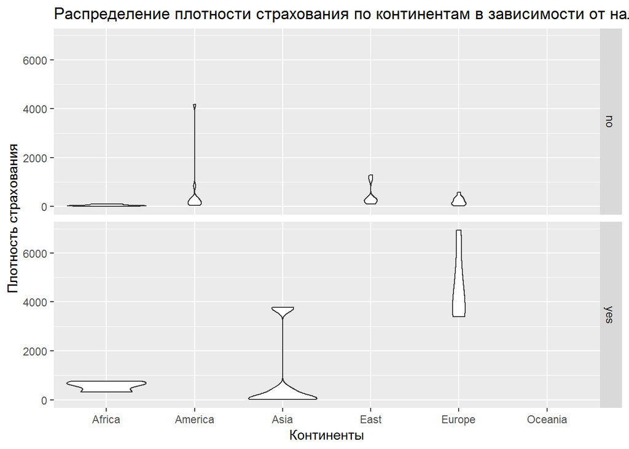

```r
ggplot(data = data) +   geom_violin(aes(x = Continents, y = Insurance_dencity)) +  facet_grid(Life_is_more ~ .) +  labs(x = 'Континенты', y = 'Плотность страхования', title = 'Распределение плотности страхования по континентам в зависимости от наличия преобладания страхования жизни (да - нижний график)')
```

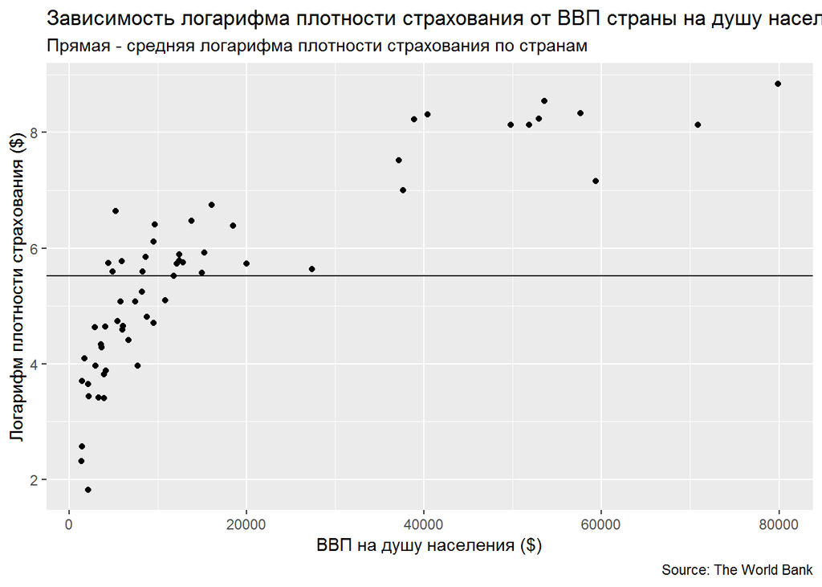

```r
ggplot(data = data) + geom_point(aes(x = GDP_per_capita, y = lnY)) +  geom_hline(aes(yintercept = mean(lnY))) +                                     labs(x = 'ВВП на душу населения ($)', y = 'Логарифм плотности страхования ($)', title = 'Зависимость логарифма плотности страхования от ВВП страны на душу населения', subtitle = 'Прямая - средняя логарифма плотности страхования по странам ', caption = 'Source: The World Bank')
```

Диаграммы дают различную интересную информацию относительно распределения плотности страхования по континентам, зависимости от ВВП (которая явно имеет нелинейную зависимость), различия в странах, где преобладает страхование жизни и не-жизни и т.п.

## 3.2 Корреляционный анализ

Отберем основные количественные переменные и проведем корреляционный анализ.

```r
data_num <- select(data, Insurance_dencity:Life_nonlife, Life, Net_trade_per_capita)
glimpse(data_num)
```

```
## Observations: 59
## Variables: 16
## $ Insurance_dencity      <dbl> 30.0, 30.5, 325.5, 3397.1, 10.2, 346.3,...
## $ Broad_money            <dbl> 79.37294, 41.80495, 28.93965, 118.53327...
## $ Commercial_bank        <dbl> 5.234463, 10.286108, 13.368897, 27.7960...
## $ Education              <dbl> 10, 6, 14, 10, 5, 14, 11, 13, 10, 11, 8...
## $ Employment_services    <dbl> 54.4, 58.4, 73.2, 75.9, 39.4, 63.3, 63....
## $ Exports                <dbl> 21.00176, 30.03023, 12.77560, 18.86783,...
## $ GDP_per_capita         <dbl> 3916.882, 3308.700, 12440.321, 49755.31...
## $ Inflation_GDP_deflator <dbl> 0.88990389, 27.42131464, 40.67530965, -...
## $ International_tourism  <dbl> 0.7892833, 3.2076979, 15.8074874, 11.68...
## $ Labor_force_rate       <dbl> 41.40755, 77.67647, 59.96354, 64.89297,...
## $ Net_trade              <dbl> -19959177831, 14548384198, 4540497887, ...
## $ Population_density     <dbl> 17.048895, 23.111786, 16.022067, 3.1515...
## $ Unemployment           <dbl> 11.5, 6.1, 8.8, 5.7, 4.1, 11.5, 7.6, 6....
## $ Life_nonlife           <dbl> 0.08333333, 0.01639344, 0.16405530, 0.4...
## $ Life                   <dbl> 2.5, 0.5, 53.4, 1558.5, 7.5, 195.5, 28....
## $ Net_trade_per_capita   <dbl> -491.53210, 504.91620, 103.55220, -237....
```

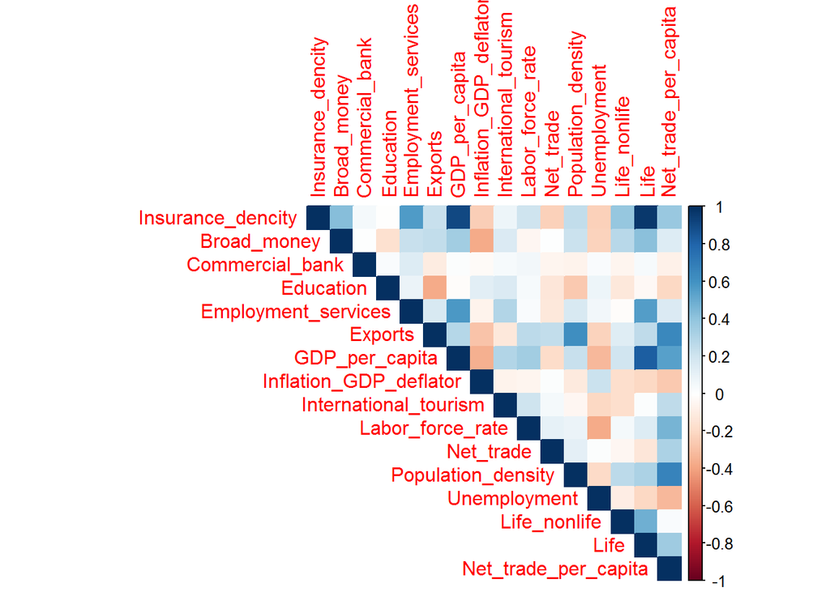

```r
data_cor <- cor(data_num, use = 'pairwise.complete.obs')
corrplot(data_cor, method = 'color', type = 'upper')
```

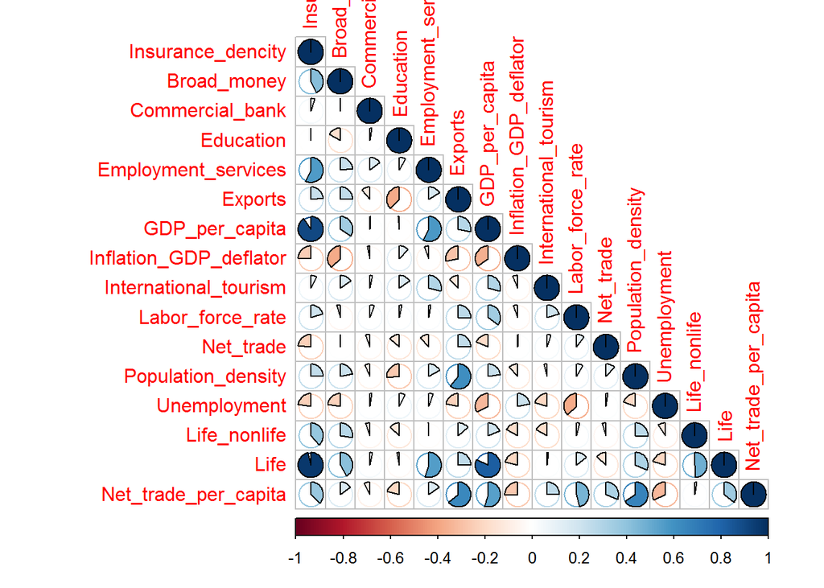

```r
corrplot(data_cor, method = 'pie', type = 'lower')
```

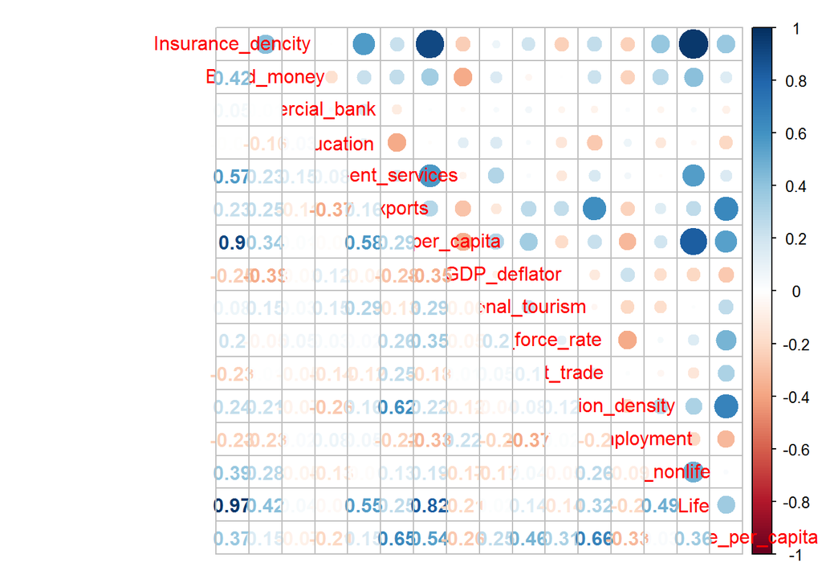

```r
corrplot.mixed(data_cor)
```

Видим, что зависимая переменная (плотность страхования) наиболее тесно положительно связана с объемом премий по страхованию жизни и с ВВП на душу населения, отрицательно - с инфляцией и безработицей (все очень логично)

# 4 Кластерный анализ

## 4.1 Масштабирование переменных

Для того, чтобы сравнивать переменные с разными единицами измерения, их масштабируют: вычитают среднее и делят на оценку стандартного отклонения.

$$x_i^* = (x_i - \bar x) / \hat \sigma_x,$$
где $\bar x = \frac{x_1 + x_2 + \ldots + x_n}{n}$, а
$$\hat\sigma_x = \frac{(x_1 - \bar x)^2 + \ldots + (x_n - \bar x)^2}{n-1}.$$

Отмасштабируем все числовые данные с помощью встроенной функции `scale()`. Результат сохраним в таблице `data_stand`.

```r
data_stand <- mutate_if(data_num, is.numeric, ~ as.vector(scale(.)))
str(data_stand)
```

```
## 'data.frame':    59 obs. of  16 variables:
##  $ Insurance_dencity     : num  -0.565 -0.564 -0.371 1.642 -0.577 ...
##  $ Broad_money           : num  -0.0364 -0.8362 -1.1101 0.7973 -0.3238 ...
##  $ Commercial_bank       : num  -0.49 -0.336 -0.242 0.199 -0.392 ...
##  $ Education             : num  -0.0406 -1.6387 1.5574 -0.0406 -2.0382 ...
##  $ Employment_services   : num  -0.533 -0.231 0.883 1.087 -1.662 ...
##  $ Exports               : num  -0.632 -0.306 -0.929 -0.709 -0.789 ...
##  $ GDP_per_capita        : num  -0.664 -0.695 -0.231 1.668 -0.795 ...
##  $ Inflation_GDP_deflator: num  -0.371 3.288 5.117 -0.551 0.434 ...
##  $ International_tourism : num  -1.303 -0.789 1.89 1.014 -1.096 ...
##  $ Labor_force_rate      : num  -2.232 1.785 -0.177 0.369 -0.567 ...
##  $ Net_trade             : num  -0.0832 0.2452 0.1499 0.0521 0.0476 ...
##  $ Population_density    : num  -0.268 -0.262 -0.269 -0.281 0.933 ...
##  $ Unemployment          : num  0.799 -0.268 0.265 -0.347 -0.663 ...
##  $ Life_nonlife          : num  -1.352 -1.631 -1.015 0.213 1.365 ...
##  $ Life                  : num  -0.508 -0.51 -0.457 1.07 -0.503 ...
##  $ Net_trade_per_capita  : num  -0.3904 -0.0258 -0.1727 -0.2975 -0.2245 ...
```

Дополнение в виде функции `as.vector` нужно потому, что функция `scale` возвращает матрицу, а каждый столбец должен быть вектором :)

## 4.2 Выбор оптимального числа кластеров

Попробуем понять, сколько кластеров брать оптимально? Один из способов сделать это — воспользоваться командой `fviz_nbclust` из пакета `factoextra`.

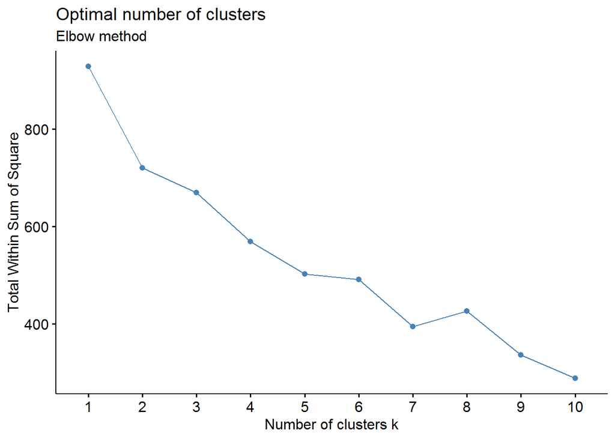

```r
g1 <- fviz_nbclust(data_stand, kmeans, method = 'wss') +
  labs(subtitle = 'Elbow method')
g1
```

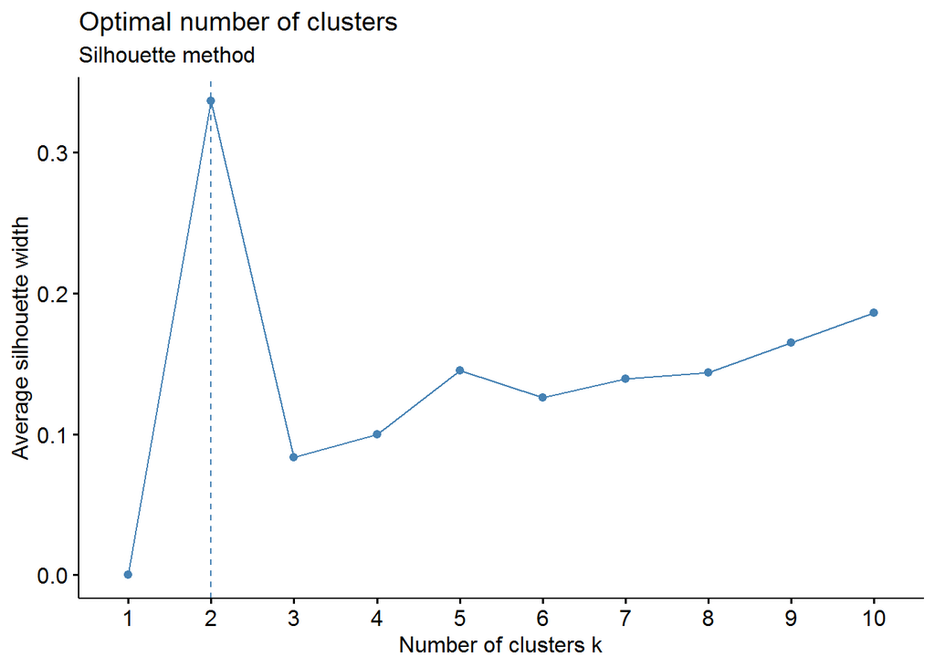

```r
g2 <- fviz_nbclust(data_stand, kmeans, method = 'silhouette') +
  labs(subtitle = 'Silhouette method')
g2
```

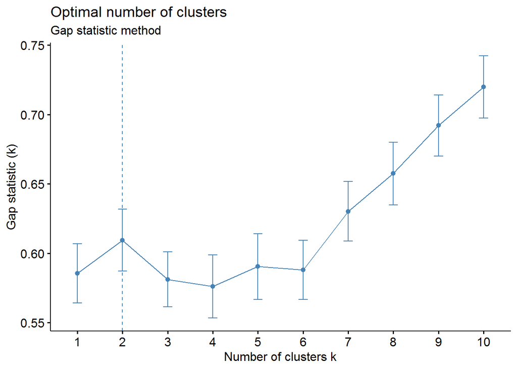

```r
g3 <- fviz_nbclust(data_stand, kmeans, method = 'gap_stat') +
  labs(subtitle = 'Gap statistic method')
g3
```

С помощью хитрого пакета Томаса (`thomasp85`) располагать графики легко И очень красиво и информативно!

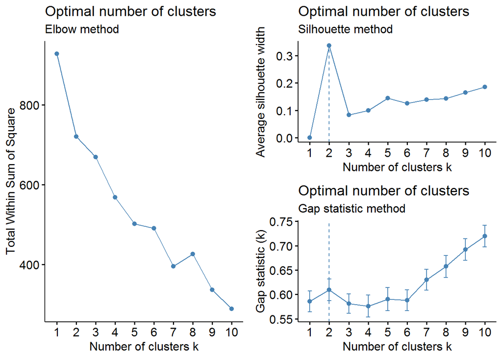

```r
g1 + (g2 / g3)
```

Итак, все три метода указывают на оптимальное число кластеров, равное 2 (или 5). Уточним число кластеров построением дендрограммы с помощью иерархического кластерного анализа.

## 4.3 Иерархическая кластеризация

Отличный способ разбить данные на группы — иерархическая кластеризация. Она не требует знания о числе кластеров и позволяет хорошо увидеть внутреннюю структуру данных и поределить оптимальное число кластеров. В отличие от метода k-средних, она работает с матрицей расстояний, поэтому первым делом посчитаем её. Для этого будем использовать функцию `dist()`. Передадим ей стандартизированные данные и укажем явно, как считать расстояния с помощью аргумента `method`.

```r
data_dist <- dist(data_stand, method = 'euclidian')
```

Расстояния тоже можно визуализировать! Сделаем это командой `fviz_dist` из пакета `factoextra`.

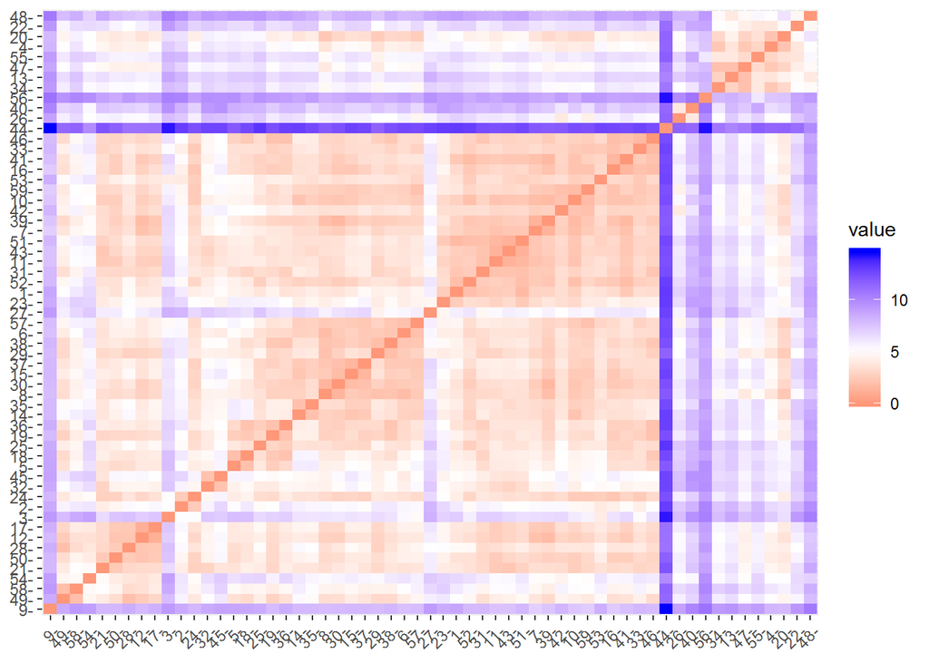

```r
fviz_dist(data_dist)
```

Полученную матрицу расстояний можно передать функции `hclust()`, которая кластеризует данные. Однако в пакете `factoextra` есть функция `hcut()`, которая работает с исходными данными. Будем использовать её и попросим выделить пять кластеров в аргументе `k`.

```r
data_hcl <- hcut(data_stand, k = 5)
```

С помощью функции `fviz_dend` визуализируем результат кластеризации. Укажем несколько аргументов, чтобы сделать дендрограмму красивее.

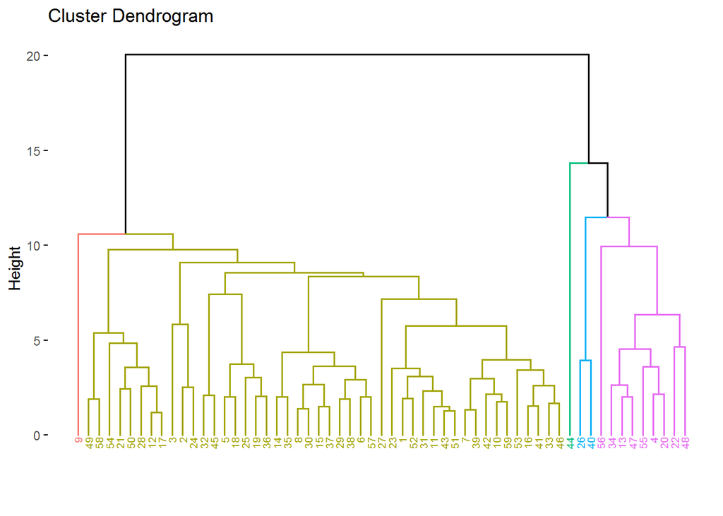

```r
fviz_dend(data_hcl,
          cex = 0.5, # размер подписи
          color_labels_by_k = TRUE) # цвет подписей по группам
```

Дендрограмма показывает наличие двух стран, существенно отличающихся от остальных стран и выделяющихся даже в отдельные кластеры - это 9 страна, Колумбия - видимо, за счет резко отличающегося от всех числа коммерческих отделений банков и 44 - Сингапур, обладающая несколькими отличными харакетристиками. Поэтому деление на 2 кластера является оптимальным - между этими группами наибольшее расстояние.

Выявленные кластеры можно добавить к исходным данным!

```r
data_plus2 <- mutate(data, cluster = data_hcl$cluster)
glimpse(data_plus2)
```

```
## Observations: 59
## Variables: 23
## $ Country                <chr> "Algeria", "Angola", "Argentina", "Aust...
## $ Continents             <fct> Africa, Africa, America, Oceania, Asia,...
## $ Insurance_dencity      <dbl> 30.0, 30.5, 325.5, 3397.1, 10.2, 346.3,...
## $ Broad_money            <dbl> 79.37294, 41.80495, 28.93965, 118.53327...
## $ Commercial_bank        <dbl> 5.234463, 10.286108, 13.368897, 27.7960...
## $ Education              <dbl> 10, 6, 14, 10, 5, 14, 11, 13, 10, 11, 8...
## $ Employment_services    <dbl> 54.4, 58.4, 73.2, 75.9, 39.4, 63.3, 63....
## $ Exports                <dbl> 21.00176, 30.03023, 12.77560, 18.86783,...
## $ GDP_per_capita         <dbl> 3916.882, 3308.700, 12440.321, 49755.31...
## $ Inflation_GDP_deflator <dbl> 0.88990389, 27.42131464, 40.67530965, -...
## $ International_tourism  <dbl> 0.7892833, 3.2076979, 15.8074874, 11.68...
## $ Labor_force_rate       <dbl> 41.40755, 77.67647, 59.96354, 64.89297,...
## $ Net_trade              <dbl> -19959177831, 14548384198, 4540497887, ...
## $ Population_density     <dbl> 17.048895, 23.111786, 16.022067, 3.1515...
## $ Unemployment           <dbl> 11.5, 6.1, 8.8, 5.7, 4.1, 11.5, 7.6, 6....
## $ Life_nonlife           <dbl> 0.08333333, 0.01639344, 0.16405530, 0.4...
## $ Life_is_more           <fct> no, no, no, no, yes, yes, no, yes, no, ...
## $ Life                   <dbl> 2.5, 0.5, 53.4, 1558.5, 7.5, 195.5, 28....
## $ `Non-life`             <dbl> 27.4, 30.0, 272.2, 1838.6, 2.7, 150.8, ...
## $ Net_trade_per_capita   <dbl> -491.53210, 504.91620, 103.55220, -237....
## $ Y_net_trade            <fct> negativ, positiv, positiv, negativ, neg...
## $ lnY                    <dbl> 3.401197, 3.417727, 5.785362, 8.130677,...
## $ cluster                <int> 1, 1, 1, 2, 1, 1, 1, 1, 3, 1, 1, 1, 2, ...
```

Иерархичская кластеризация полезна и для визуализаций корреляций. Если в функции `corrplot()` из одноимённого пакета указать аргумента `order = hclust`, то мы получим сгруппированные по кластерам переменные. Для красоты добавим ещё один аргумент — `addrect = ...`. Он обведёт прямоугольниками указанное число кластеров.

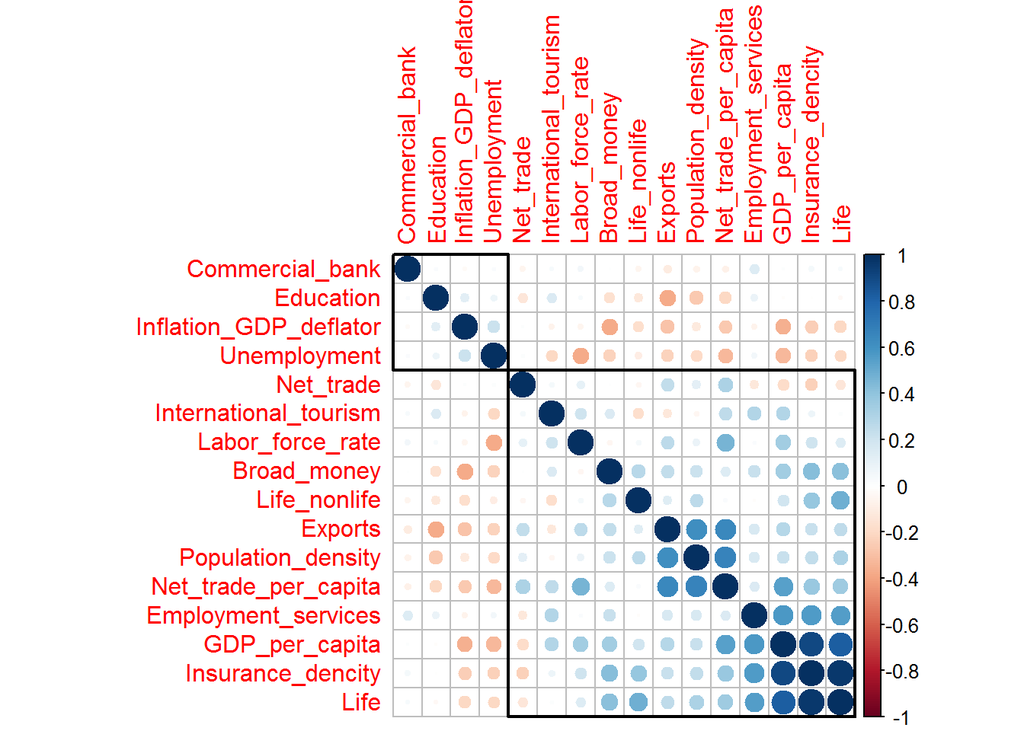

```r
data_cor <- cor(data_stand)
corrplot(data_cor, order = 'hclust', addrect = 2)
```

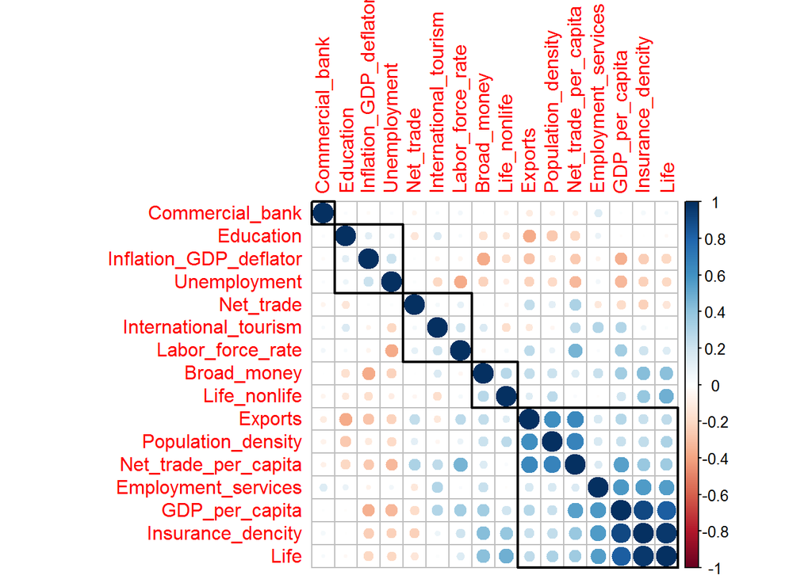

```r
corrplot(data_cor, order = 'hclust', addrect = 5)
```

## 4.4 Кластеризация методом k-средних

Выполним кластеризацию методом k-средних с помощью функции `kmeans`.

В качестве аргументов укажем отмасштабированные данные `data_stand` и количество кластеров `centers`. Оптимальное количество кластеров согласно всем предыдущим исследованиям равно 2. Сохраним результат этого действия в список `k_means_data`.

```r
set.seed(13)
k_means_data <- kmeans(data_stand, centers = 2)
k_means_data
```

```
## K-means clustering with 2 clusters of sizes 13, 46
##
## Cluster means:
##   Insurance_dencity Broad_money Commercial_bank   Education
## 1         1.5603612   0.6984174    -0.006396180 -0.16355427
## 2        -0.4409717  -0.1973788     0.001807616  0.04622186
##   Employment_services    Exports GDP_per_capita Inflation_GDP_deflator
## 1           1.0004902  0.4834203      1.7088693             -0.6912615
## 2          -0.2827472 -0.1366188     -0.4829413              0.1953565
##   International_tourism Labor_force_rate  Net_trade Population_density
## 1             0.6360328        0.6803755 -0.3586987          0.4567021
## 2            -0.1797484       -0.1922800  0.1013714         -0.1290680
##   Unemployment Life_nonlife       Life Net_trade_per_capita
## 1   -0.6481390    0.4474750  1.4673702            0.9410784
## 2    0.1831697   -0.1264603 -0.4146916           -0.2659569
##
## Clustering vector:
##  [1] 2 2 2 1 2 2 2 2 2 2 2 2 1 2 2 2 2 2 2 1 2 1 2 2 2 1 2 2 2 2 2 2 2 1 2
## [36] 2 2 2 2 1 2 2 2 1 2 2 1 1 2 2 2 2 2 1 1 1 2 2 2
##
## Within cluster sum of squares by cluster:
## [1] 300.2807 420.1979
##  (between_SS / total_SS =  22.4 %)
##
## Available components:
##
## [1] "cluster"      "centers"      "totss"        "withinss"
## [5] "tot.withinss" "betweenss"    "size"         "iter"
## [9] "ifault"
```

Посмотрим на содержимое списка `k_means_data` командой `attributes()`.

```r
attributes(k_means_data)
```

```
## $names
## [1] "cluster"      "centers"      "totss"        "withinss"
## [5] "tot.withinss" "betweenss"    "size"         "iter"
## [9] "ifault"
##
## $class
## [1] "kmeans"
```

Помним также, что в Rstudio можно кликнуть на лупу справа от `k_means_protein` во вкладке `Environment`.

Теперь, зная, что искать, мы можем посмотреть, например, на координаты центра кластеров или количество объектов в каждом из них.

```r
k_means_data$centers
```

```
##   Insurance_dencity Broad_money Commercial_bank   Education
## 1         1.5603612   0.6984174    -0.006396180 -0.16355427
## 2        -0.4409717  -0.1973788     0.001807616  0.04622186
##   Employment_services    Exports GDP_per_capita Inflation_GDP_deflator
## 1           1.0004902  0.4834203      1.7088693             -0.6912615
## 2          -0.2827472 -0.1366188     -0.4829413              0.1953565
##   International_tourism Labor_force_rate  Net_trade Population_density
## 1             0.6360328        0.6803755 -0.3586987          0.4567021
## 2            -0.1797484       -0.1922800  0.1013714         -0.1290680
##   Unemployment Life_nonlife       Life Net_trade_per_capita
## 1   -0.6481390    0.4474750  1.4673702            0.9410784
## 2    0.1831697   -0.1264603 -0.4146916           -0.2659569
```

```r
k_means_data$cluster
```

```
##  [1] 2 2 2 1 2 2 2 2 2 2 2 2 1 2 2 2 2 2 2 1 2 1 2 2 2 1 2 2 2 2 2 2 2 1 2
## [36] 2 2 2 2 1 2 2 2 1 2 2 1 1 2 2 2 2 2 1 1 1 2 2 2
```

```r
k_means_data$size
```

```
## [1] 13 46
```

Другой способ структурировать вывод `kmeans` — использовать команду `tidy` из пакета `broom`.

```r
tidy(k_means_data)
```

| x1 | x2 | x3 | x4 | x5 | x6 | x7 | x8 | x9 | x10 | x11 | x12 | x13 | x14 | x15 | x16 | size | withinss | cluster |
| --- | --- | --- | --- | --- | --- | --- | --- | --- | --- | --- | --- | --- | --- | --- | --- | --- | --- | --- |
| 1.56 | 0.698 | -0.0064 | -0.164 | 1 | 0.483 | 1.71 | -0.691 | 0.636 | 0.68 | -0.359 | 0.457 | -0.648 | 0.447 | 1.47 | 0.941 | 13 | 300 | 1 |
| -0.441 | -0.197 | 0.00181 | 0.0462 | -0.283 | -0.137 | -0.483 | 0.195 | -0.18 | -0.192 | 0.101 | -0.129 | 0.183 | -0.126 | -0.415 | -0.266 | 46 | 420 | 2 |

Осталось только визуализировать результаты! Для этого будем использовать команду `fviz_cluster()` из пакета `factoextra`. Её аргументы — результат кластеризации `k_means_data`, исходные данные и ещё куча настроек вроде размера точек и цвета наблюдений-выбросов. Мы только попросим выделять цветом кластеры по их границам и укажем аргумент `ellipse.type = 'convex'`.

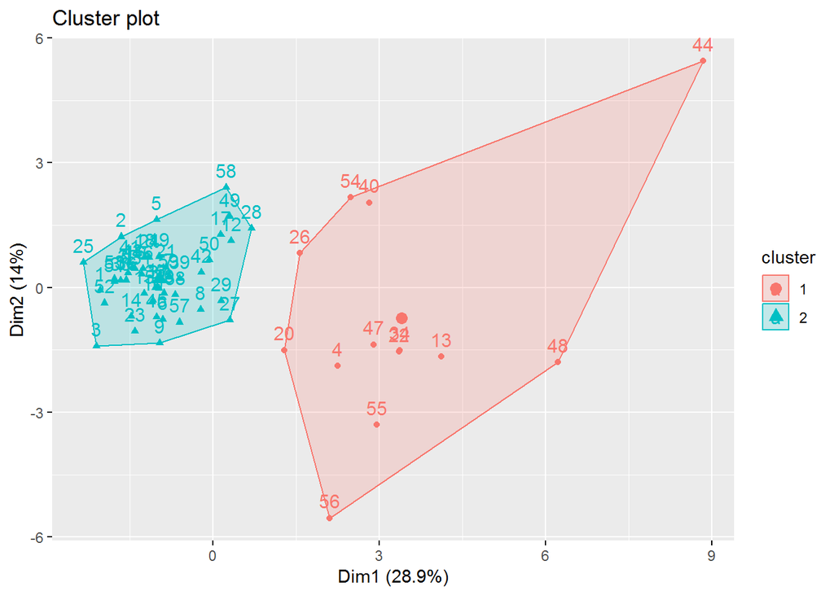

```r
fviz_cluster(object = k_means_data, data = data_stand,
             ellipse.type = 'convex')
```

Видим, что кластеры получились вполне различимы в простраснтве признаков и не пересекаются. Метки кластерам легко добавить к исходным данным:

```r
data_plus <- mutate(data, cluster = k_means_data$cluster)
glimpse(data_plus)
```

```
## Observations: 59
## Variables: 23
## $ Country                <chr> "Algeria", "Angola", "Argentina", "Aust...
## $ Continents             <fct> Africa, Africa, America, Oceania, Asia,...
## $ Insurance_dencity      <dbl> 30.0, 30.5, 325.5, 3397.1, 10.2, 346.3,...
## $ Broad_money            <dbl> 79.37294, 41.80495, 28.93965, 118.53327...
## $ Commercial_bank        <dbl> 5.234463, 10.286108, 13.368897, 27.7960...
## $ Education              <dbl> 10, 6, 14, 10, 5, 14, 11, 13, 10, 11, 8...
## $ Employment_services    <dbl> 54.4, 58.4, 73.2, 75.9, 39.4, 63.3, 63....
## $ Exports                <dbl> 21.00176, 30.03023, 12.77560, 18.86783,...
## $ GDP_per_capita         <dbl> 3916.882, 3308.700, 12440.321, 49755.31...
## $ Inflation_GDP_deflator <dbl> 0.88990389, 27.42131464, 40.67530965, -...
## $ International_tourism  <dbl> 0.7892833, 3.2076979, 15.8074874, 11.68...
## $ Labor_force_rate       <dbl> 41.40755, 77.67647, 59.96354, 64.89297,...
## $ Net_trade              <dbl> -19959177831, 14548384198, 4540497887, ...
## $ Population_density     <dbl> 17.048895, 23.111786, 16.022067, 3.1515...
## $ Unemployment           <dbl> 11.5, 6.1, 8.8, 5.7, 4.1, 11.5, 7.6, 6....
## $ Life_nonlife           <dbl> 0.08333333, 0.01639344, 0.16405530, 0.4...
## $ Life_is_more           <fct> no, no, no, no, yes, yes, no, yes, no, ...
## $ Life                   <dbl> 2.5, 0.5, 53.4, 1558.5, 7.5, 195.5, 28....
## $ `Non-life`             <dbl> 27.4, 30.0, 272.2, 1838.6, 2.7, 150.8, ...
## $ Net_trade_per_capita   <dbl> -491.53210, 504.91620, 103.55220, -237....
## $ Y_net_trade            <fct> negativ, positiv, positiv, negativ, neg...
## $ lnY                    <dbl> 3.401197, 3.417727, 5.785362, 8.130677,...
## $ cluster                <int> 2, 2, 2, 1, 2, 2, 2, 2, 2, 2, 2, 2, 1, ...
```

# 5 Построение линейных множественных регрессий зависимости плотности страхования от основных макроэкономических индикаторов развития стран

Итак, за зависимую переменную принимаем логарифм плотности страхования (предпосылка использования классической линейной регрессии - нормальность зависимой переменной) от разных наборов признаков. Для этого построим длинную и короткую регрессии.

## 5.1 Длинная регрессия

Сначала построим длинную регрессию с самыми коррелированными факторными признаками - ВВП на душу населения, премиями по страхованию жизни на душу населения, долей страхования жизни в общем объеме премий, широкой денежной массой, занятостью в сфере услуг, плотностью населения, продажей товаров и услуг, безработицей, экспортом добавим в качестве дамми факторные переменные континента и преобладания страхования жизни

```r
glimpse(data)
```

```
## Observations: 59
## Variables: 22
## $ Country                <chr> "Algeria", "Angola", "Argentina", "Aust...
## $ Continents             <fct> Africa, Africa, America, Oceania, Asia,...
## $ Insurance_dencity      <dbl> 30.0, 30.5, 325.5, 3397.1, 10.2, 346.3,...
## $ Broad_money            <dbl> 79.37294, 41.80495, 28.93965, 118.53327...
## $ Commercial_bank        <dbl> 5.234463, 10.286108, 13.368897, 27.7960...
## $ Education              <dbl> 10, 6, 14, 10, 5, 14, 11, 13, 10, 11, 8...
## $ Employment_services    <dbl> 54.4, 58.4, 73.2, 75.9, 39.4, 63.3, 63....
## $ Exports                <dbl> 21.00176, 30.03023, 12.77560, 18.86783,...
## $ GDP_per_capita         <dbl> 3916.882, 3308.700, 12440.321, 49755.31...
## $ Inflation_GDP_deflator <dbl> 0.88990389, 27.42131464, 40.67530965, -...
## $ International_tourism  <dbl> 0.7892833, 3.2076979, 15.8074874, 11.68...
## $ Labor_force_rate       <dbl> 41.40755, 77.67647, 59.96354, 64.89297,...
## $ Net_trade              <dbl> -19959177831, 14548384198, 4540497887, ...
## $ Population_density     <dbl> 17.048895, 23.111786, 16.022067, 3.1515...
## $ Unemployment           <dbl> 11.5, 6.1, 8.8, 5.7, 4.1, 11.5, 7.6, 6....
## $ Life_nonlife           <dbl> 0.08333333, 0.01639344, 0.16405530, 0.4...
## $ Life_is_more           <fct> no, no, no, no, yes, yes, no, yes, no, ...
## $ Life                   <dbl> 2.5, 0.5, 53.4, 1558.5, 7.5, 195.5, 28....
## $ `Non-life`             <dbl> 27.4, 30.0, 272.2, 1838.6, 2.7, 150.8, ...
## $ Net_trade_per_capita   <dbl> -491.53210, 504.91620, 103.55220, -237....
## $ Y_net_trade            <fct> negativ, positiv, positiv, negativ, neg...
## $ lnY                    <dbl> 3.401197, 3.417727, 5.785362, 8.130677,...
```

```r
model_long1 <- lm(data = data, lnY ~ GDP_per_capita + Life + Life_nonlife + Broad_money + Employment_services + Population_density + Exports + Net_trade_per_capita + Unemployment + Continents +  Life_is_more )
```

С помощью команды `summary()` посмотрим на описание модели.

```r
summary(model_long1)
```

```
##
## Call:
## lm(formula = lnY ~ GDP_per_capita + Life + Life_nonlife + Broad_money +
##     Employment_services + Population_density + Exports + Net_trade_per_capita +
##     Unemployment + Continents + Life_is_more, data = data)
##
## Residuals:
##      Min       1Q   Median       3Q      Max
## -1.53863 -0.32937  0.09854  0.38994  0.93569
##
## Coefficients:
##                        Estimate Std. Error t value Pr(>|t|)
## (Intercept)           8.959e-01  7.061e-01   1.269 0.211340
## GDP_per_capita        5.338e-05  1.335e-05   3.997 0.000247 ***
## Life                  4.838e-05  2.546e-04   0.190 0.850210
## Life_nonlife          2.218e+00  8.795e-01   2.521 0.015475 *
## Broad_money           5.025e-03  2.468e-03   2.036 0.047921 *
## Employment_services   2.108e-02  1.100e-02   1.916 0.062071 .
## Population_density   -2.061e-04  1.541e-04  -1.337 0.188106
## Exports               1.539e-02  5.344e-03   2.880 0.006171 **
## Net_trade_per_capita -4.184e-05  7.232e-05  -0.579 0.565941
## Unemployment          4.436e-02  2.350e-02   1.887 0.065860 .
## ContinentsAmerica     8.908e-01  3.358e-01   2.652 0.011148 *
## ContinentsAsia       -1.948e-01  3.958e-01  -0.492 0.625214
## ContinentsEast        6.374e-01  4.164e-01   1.531 0.133088
## ContinentsEurope      2.104e-01  3.520e-01   0.598 0.553115
## ContinentsOceania     7.384e-01  8.049e-01   0.917 0.364080
## Life_is_moreyes      -2.308e-01  4.185e-01  -0.552 0.584092
## ---
## Signif. codes:  0 '***' 0.001 '**' 0.01 '*' 0.05 '.' 0.1 ' ' 1
##
## Residual standard error: 0.6537 on 43 degrees of freedom
## Multiple R-squared:  0.8859, Adjusted R-squared:  0.8461
## F-statistic: 22.26 on 15 and 43 DF,  p-value: 1.738e-15
```

Видим, что, как и можно было ожидать из матрицы корреляций, значимых переменных не так много.

Построим регрессию, оставив только значимые переменные - регрессия будет с ВВП на душу населения, долей страхования жизни в общем объеме премий, широкой денежной массой, занятостью в сфере услуг, экспортом и безработицей

```r
model_long2 <- lm(data = data, lnY ~ GDP_per_capita +  Life_nonlife + Broad_money + Employment_services +  Exports + Unemployment)
summary(model_long2)
```

```
##
## Call:
## lm(formula = lnY ~ GDP_per_capita + Life_nonlife + Broad_money +
##     Employment_services + Exports + Unemployment, data = data)
##
## Residuals:
##     Min      1Q  Median      3Q     Max
## -2.1811 -0.4335  0.1527  0.3885  1.4561
##
## Coefficients:
##                      Estimate Std. Error t value Pr(>|t|)
## (Intercept)         1.044e+00  5.553e-01   1.880 0.065737 .
## GDP_per_capita      5.194e-05  6.834e-06   7.600 5.47e-10 ***
## Life_nonlife        1.132e+00  4.191e-01   2.701 0.009303 **
## Broad_money         4.303e-03  2.254e-03   1.910 0.061711 .
## Employment_services 3.742e-02  9.361e-03   3.998 0.000203 ***
## Exports             4.521e-03  3.641e-03   1.242 0.219887
## Unemployment        4.173e-02  2.124e-02   1.964 0.054863 .
## ---
## Signif. codes:  0 '***' 0.001 '**' 0.01 '*' 0.05 '.' 0.1 ' ' 1
##
## Residual standard error: 0.7188 on 52 degrees of freedom
## Multiple R-squared:  0.8332, Adjusted R-squared:  0.814
## F-statistic: 43.29 on 6 and 52 DF,  p-value: < 2.2e-16
```

Исключим еще одну ставшую незначимой переменную - экспорт

```r
model_long <- lm(data = data, lnY ~ GDP_per_capita +  Life_nonlife + Broad_money + Employment_services +  Unemployment)
summary(model_long)
```

```
##
## Call:
## lm(formula = lnY ~ GDP_per_capita + Life_nonlife + Broad_money +
##     Employment_services + Unemployment, data = data)
##
## Residuals:
##     Min      1Q  Median      3Q     Max
## -2.2786 -0.4003  0.1598  0.3748  1.4430
##
## Coefficients:
##                      Estimate Std. Error t value Pr(>|t|)
## (Intercept)         1.160e+00  5.501e-01   2.109 0.039722 *
## GDP_per_capita      5.299e-05  6.816e-06   7.774 2.57e-10 ***
## Life_nonlife        1.159e+00  4.207e-01   2.755 0.008025 **
## Broad_money         4.672e-03  2.245e-03   2.080 0.042332 *
## Employment_services 3.781e-02  9.403e-03   4.021 0.000185 ***
## Unemployment        3.847e-02  2.119e-02   1.816 0.075080 .
## ---
## Signif. codes:  0 '***' 0.001 '**' 0.01 '*' 0.05 '.' 0.1 ' ' 1
##
## Residual standard error: 0.7225 on 53 degrees of freedom
## Multiple R-squared:  0.8283, Adjusted R-squared:  0.8121
## F-statistic: 51.12 on 5 and 53 DF,  p-value: < 2.2e-16
```

Теперь все коэффициенты регрессии значимы, по крайней мере на уровне значимости 0,1, эту регрессию и назовем длинной.

Другой способ посмотреть на описание модели — воспользоваться функциями пакета `broom`. Оценки коэффциентов, стандартные ошибки, p-значения выводит команда `tidy()`:

```r
tidy(model_long)
```

| term | estimate | std.error | statistic | p.value |
| --- | --- | --- | --- | --- |
| (Intercept) | 1.16 | 0.55 | 2.11 | 0.0397 |
| GDP_per_capita | 5.3e-05 | 6.82e-06 | 7.77 | 2.57e-10 |
| Life_nonlife | 1.16 | 0.421 | 2.76 | 0.00803 |
| Broad_money | 0.00467 | 0.00225 | 2.08 | 0.0423 |
| Employment_services | 0.0378 | 0.0094 | 4.02 | 0.000185 |
| Unemployment | 0.0385 | 0.0212 | 1.82 | 0.0751 |

А функция `glance()` покажет общие характеристики модели, для которых достаточно одной строчки, — коэффциент детерминации, значение лог-функции правдоподобия, AIC, BIC…

```r
glance(model_long)
```

| r.squared | adj.r.squared | sigma | statistic | p.value | df | logLik | AIC | BIC | deviance | df.residual |
| --- | --- | --- | --- | --- | --- | --- | --- | --- | --- | --- |
| 0.828 | 0.812 | 0.722 | 51.1 | 4.44e-19 | 6 | -61.4 | 137 | 151 | 27.7 | 53 |

Если из общей таблицы описания модели нужна только информация о коэффициентах, то поможет команда `coeftest()` из пакета `lmtest()`.

```r
coeftest(model_long)
```

```
##
## t test of coefficients:
##
##                       Estimate Std. Error t value  Pr(>|t|)
## (Intercept)         1.1600e+00 5.5015e-01  2.1086 0.0397220 *
## GDP_per_capita      5.2990e-05 6.8160e-06  7.7744 2.569e-10 ***
## Life_nonlife        1.1590e+00 4.2070e-01  2.7551 0.0080253 **
## Broad_money         4.6716e-03 2.2454e-03  2.0805 0.0423323 *
## Employment_services 3.7807e-02 9.4033e-03  4.0206 0.0001848 ***
## Unemployment        3.8474e-02 2.1190e-02  1.8157 0.0750795 .
## ---
## Signif. codes:  0 '***' 0.001 '**' 0.01 '*' 0.05 '.' 0.1 ' ' 1
```

Посмотрим модель подробнее

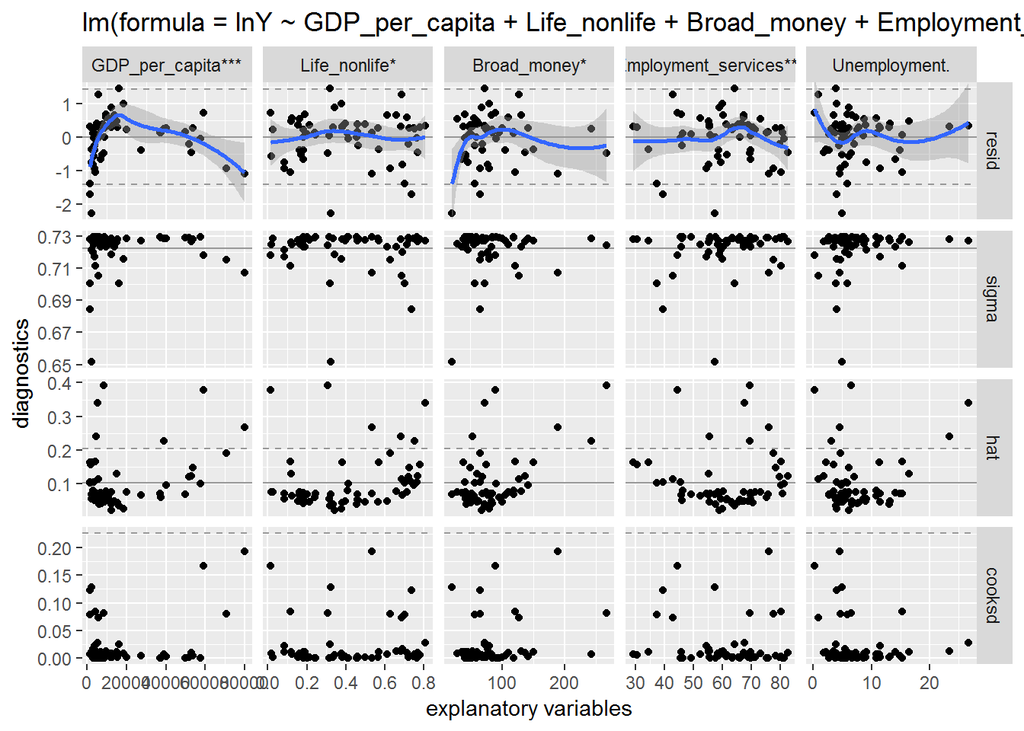

```r
ggnostic(model = model_long)
```

В модели, конечно, есть выбросы, но мы это уже оценили на этапе кластерного анализа.

чnо позволяет количественно оценить влияние каждого фактора на плотность страхования/ Модель значима, объясняет 82,8% дисперсии зависимой переменной, имеет все значимые коэффициенты регресси вполне может использоваться для практических выводов.

Нарисуем линию регрессии для модели, задав по оси Х самый значимый факторный признак - ВВП на душу населения. Для этого к диаграмме рассеяния добавим дополнительный слой `geom_smooth()`. Внутри него за линейную регрессию отвечает `method = 'lm'`.

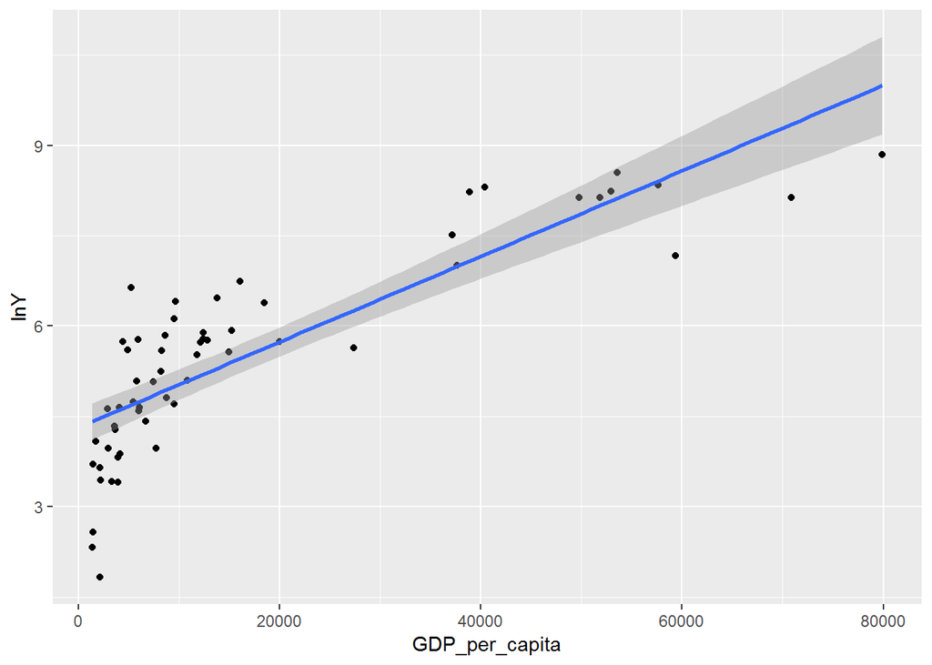

```r
ggplot(data = data, aes(x = GDP_per_capita, y=lnY)) +
  geom_point() +
  geom_smooth(method = 'lm')
```

## 5.2 Короткая регрессия

Теперь построим короткую регрессию с самыми значимыми регрессорами - ВВП на душу населения, долей страхования жизни в общем объеме премий и занятостью в сфере услуг

```r
model_short <- lm(data = data, lnY ~ GDP_per_capita +  Life_nonlife + Employment_services)
summary(model_short)
```

```
##
## Call:
## lm(formula = lnY ~ GDP_per_capita + Life_nonlife + Employment_services,
##     data = data)
##
## Residuals:
##     Min      1Q  Median      3Q     Max
## -2.6482 -0.4141  0.1346  0.4753  1.2667
##
## Coefficients:
##                      Estimate Std. Error t value Pr(>|t|)
## (Intercept)         1.355e+00  5.664e-01   2.393  0.02015 *
## GDP_per_capita      5.032e-05  6.345e-06   7.930 1.13e-10 ***
## Life_nonlife        1.387e+00  4.242e-01   3.270  0.00186 **
## Employment_services 4.469e-02  9.218e-03   4.848 1.06e-05 ***
## ---
## Signif. codes:  0 '***' 0.001 '**' 0.01 '*' 0.05 '.' 0.1 ' ' 1
##
## Residual standard error: 0.7519 on 55 degrees of freedom
## Multiple R-squared:  0.807,  Adjusted R-squared:  0.7964
## F-statistic: 76.64 on 3 and 55 DF,  p-value: < 2.2e-16
```

```r
tidy(model_short)
```

| term | estimate | std.error | statistic | p.value |
| --- | --- | --- | --- | --- |
| (Intercept) | 1.36 | 0.566 | 2.39 | 0.0202 |
| GDP_per_capita | 5.03e-05 | 6.34e-06 | 7.93 | 1.13e-10 |
| Life_nonlife | 1.39 | 0.424 | 3.27 | 0.00186 |
| Employment_services | 0.0447 | 0.00922 | 4.85 | 1.06e-05 |

```r
glance(model_short)
```

| r.squared | adj.r.squared | sigma | statistic | p.value | df | logLik | AIC | BIC | deviance | df.residual |
| --- | --- | --- | --- | --- | --- | --- | --- | --- | --- | --- |
| 0.807 | 0.796 | 0.752 | 76.6 | 1.23e-19 | 4 | -64.8 | 140 | 150 | 31.1 | 55 |

Здесь, конечно же, все коэффициенты регрессии значимы, и коэффициент детерминации (скоррективроанный) упал не так сильно - до 79,6%.

## 5.3 Сравнение длинной и короткой регрессий

Сравним длинную и короткую модели.Если есть две вложенных модели, то есть одна является частным случаем другой, то можно провести тест Вальда, чтобы выбрать одну из них.

$H_0$: верна ограниченная (короткая) модель;

$H_1$: верная неограниченная (длинная) модель;

```r
waldtest( model_short, model_long)
```

| Res.Df | Df | F | Pr(>F) |
| --- | --- | --- | --- |
| 55 |  |  |  |
| 53 | 2 | 3.29 | 0.0451 |

p-value=0,045 говорит, что на уровне значимости 0,05 гипотезу о принятии короткой регресси надо отвергнуть в пользу длинной (хотя на другом уровне значимости она не будет отвергнута, что говорит о не таком уж и плохом ее качестве, как мы и отмечали уже). Поэтому длинная регрессия лучше.

Больше, к сожалению, не успеваю, увлеклась сильно началом (хотя знаю и разобралась, как дальше делать :( )

Но итак исследование получилось очень интересное и информативное!

# 6 Спасибо за курс!

## 6.1 Ура! :)